# getVOT

## The procedure: negative VOT

- We note the maximum amplitude in 1 ms windows.

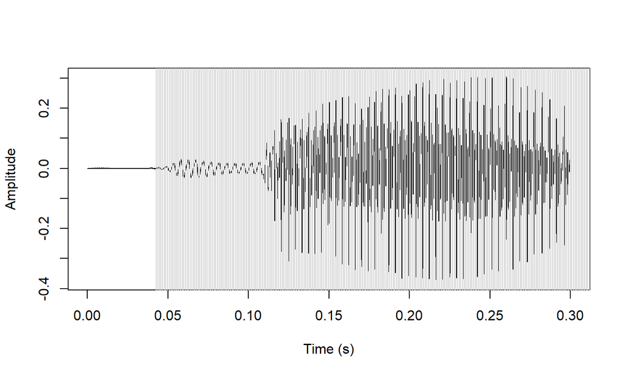

## The procedure: negative VOT

- This results in a time series that looks like this:

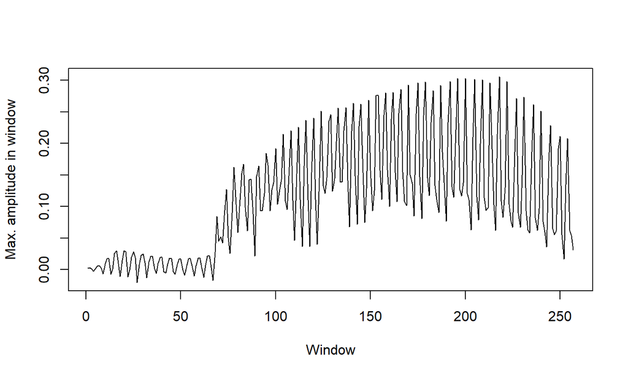

## The procedure: negative VOT

- This is actually really difficult to use, because it’s too jagged.
  - So we smooth this time series using DCT.

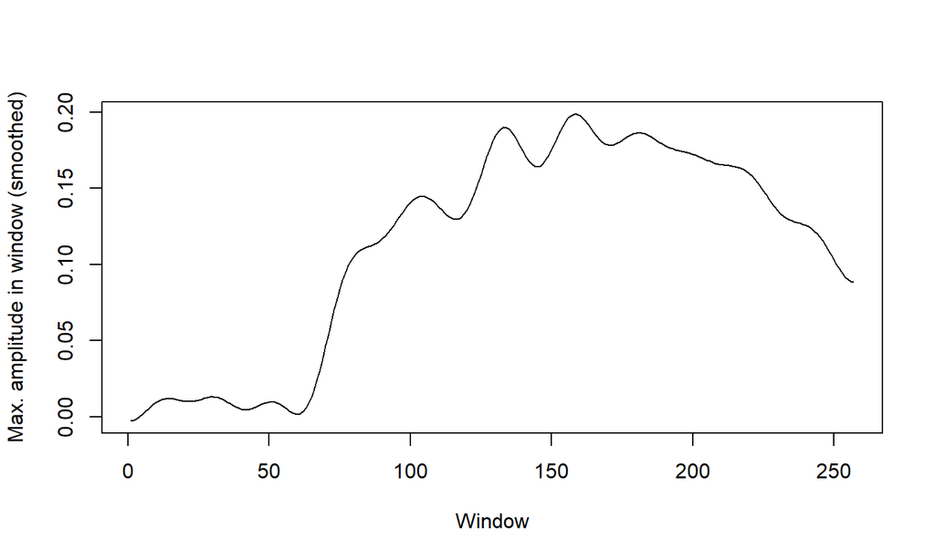

## The procedure: negative VOT

- The predicted stop release is when we see the highest velocity in this time series.

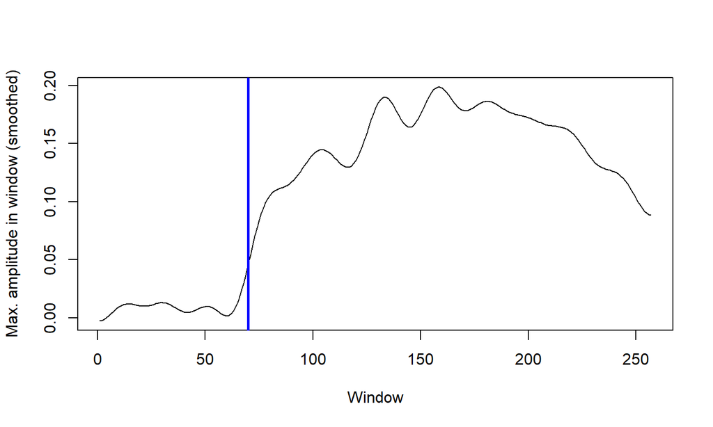

- In our sound wave, it looks like this:

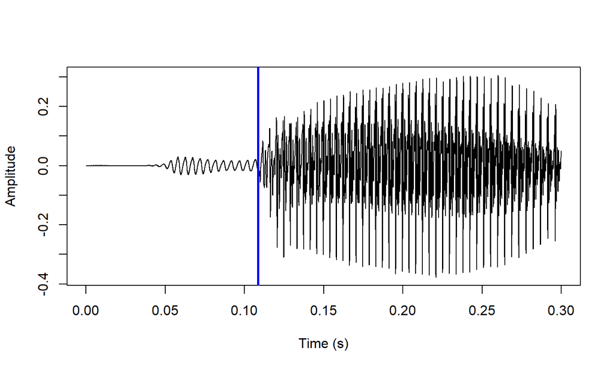

## The procedure: negative VOT

- This was our hand-measured VOT:

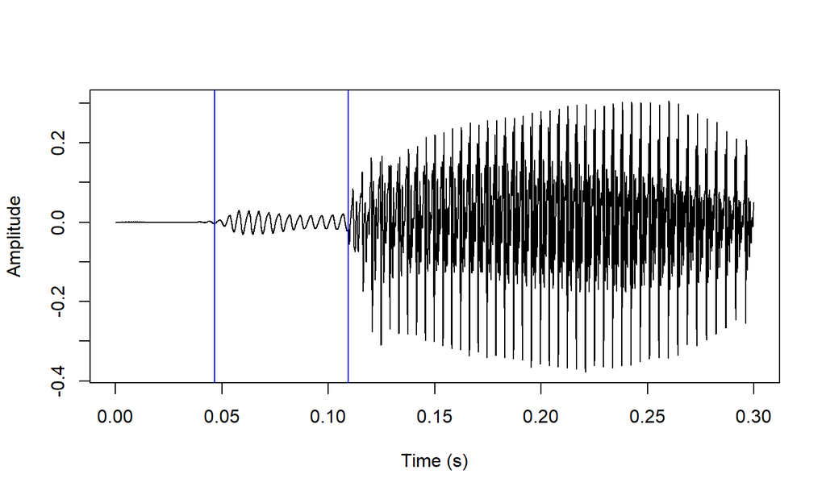

## The procedure: negative VOT

- This is the VOT we predicted using the transient method:

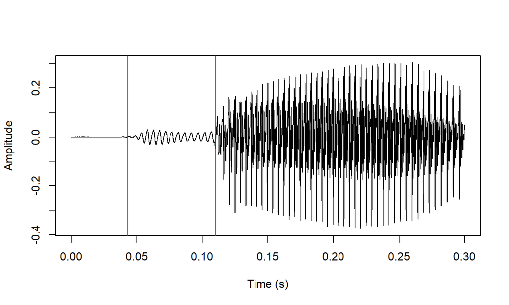

## The procedure: negative VOT

- And this is the VOT we predicted using the amplitude method:

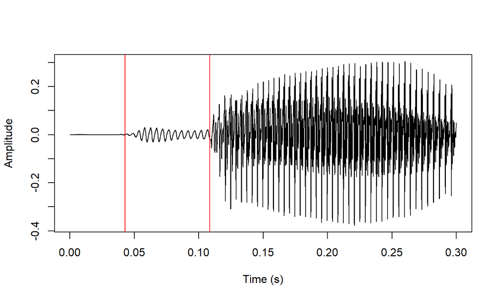

## Parameter settings

- This is implemented in the `getVOT` functions `positiveVOT` and `negativeVOT`.
- These take the rather obscure arguments we’ve discussed throughout, and some we haven’t.

```r
args(positiveVOT)
```

```
## function (sound, sr, closure_interval = 10, release_param = 15,
##     vo_method = "acf", vo_granularity = 1, vo_param = 0.85, f0_wl = 30,
##     f0_minacf = 0.5, burst_only = FALSE, f0_first = FALSE, plot = TRUE,
##     params_list = NULL)
## NULL
```

## Parameter settings

- To help setting these, `getVOT` has the functions `neg_setParams` and `pos_setParams`.
- Let’s try this out on our voiced stop.

```r
negParams <- neg_setParams(directory='voi', plot=F)
```

`[1] "Testing voicing onset parameter settings for baa.wav"`  
`[1] "On average, the selected parameters for voicing onset after a first pass agree with the training data within a margin of 0.285 ms"`  
`[1] "Finetuning voicing onset parameter settings for baa.wav"`  
`[1] "On average, the selected voicing onset parameters after finetuning agree with the training data within a margin of 0.092 ms"`  
`[1] "Testing accuracy of different burst detection methods baa.wav"`  
`[1] "On average, the select burst detection method agreewith the training data within a margin of 0.507 ms"`

## Parameter settings

- We could’ve gotten slightly better results for this one stop with different parameters.
- Usually the `setParams` functions should be used with 5-10 files.
  - The returned list of parameters then minimizes the difference between hand-annotation and prediction.
- `plot_training_diff` will visualize the comparison between hand-annotated and predicted VOT.

## Parameter settings

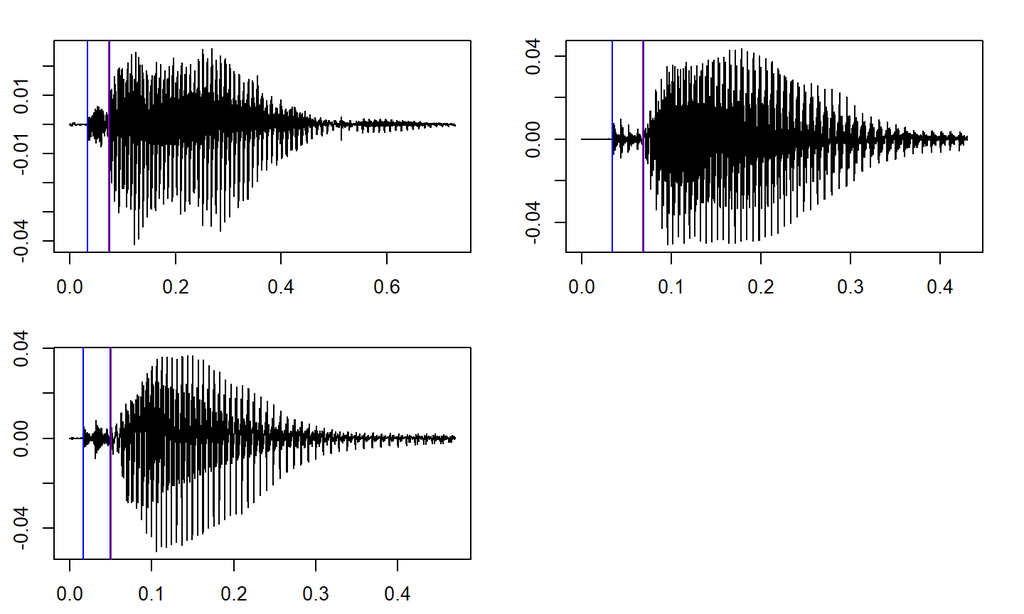

```r
plot_training_diff(directory='pos_training', params_list=plotParams)
```

## Parameter settings and cats

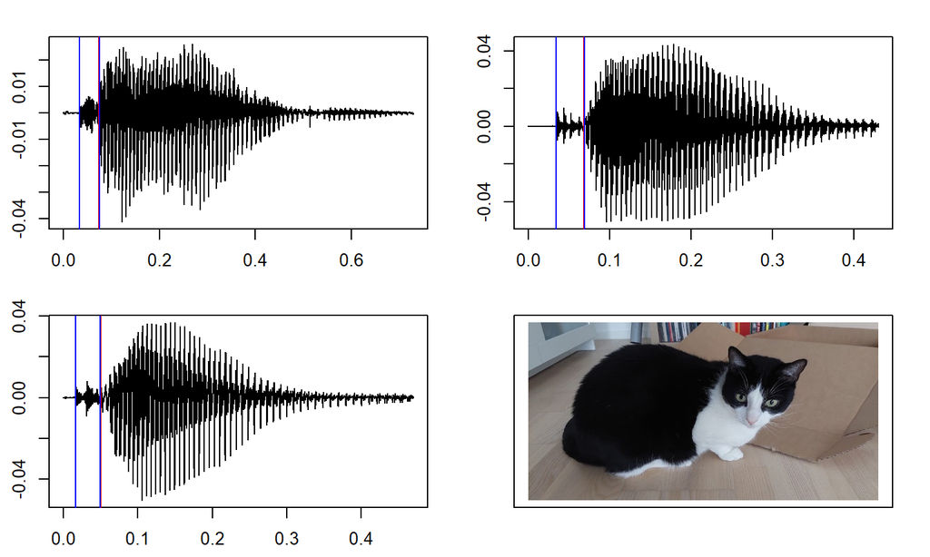

```r
plot_training_diff(directory='pos_training', params_list=plotParams,
                   cat=TRUE)
```

## From `R` to Praat

- Okay, so the functions `positiveVOT` and `negativeVOT` can predict VOT for individual sound files, but how is this useful?

```r
negativeVOT(sound[,1], 44100, params_list=negParams, plot=FALSE)
```

```
## $vo
## [1] 2050.95
##
## $rel
## [1] 4849.35
##
## $vot
## [1] -63.5
##
## $voi_int
## [1] 252
```

## From `R` to Praat

- Probably the two most important functions of `getVOT` are:
- `VOT2newTG`
  - For sound files containing a single word, will generate new TextGrids with predicted VOT.
- `addVOT2TG`
  - For longer sound files with existing TextGrids, will add a new tier with predicted VOT.

## From `R` to Praat

```r
VOT2newTG(directory='voi',
          sign='negative',
          neg_params_list=negParams)
```

```r
addVOT2TG(directory='DanPASS_mono',
          seg_list=c('p', 't', 'k'),
          tg_tier='lydskrift',
          sign='positive')
```

## Let’s try it out!

```r
devtools::install.github('rpuggaardrode/getVOT')
```

```r
VOT2newTG(directory='YOUR DIRECTORY NAME HERE', sign='positive')
```

- If results are poor, try the following:

```r
VOT2newTG(MY_PARAMS <- pos_setParams('YOUR DIRECTORY NAME HERE'))
```